# HW 2

Autumn Li and UNI ql2280

Oct,03 2016

# Part 1: Loading and Cleaning the Data in R

1. Load the data into a dataframe called housing.
2. How many rows and columns does the dataframe have?

```r
data2 = "~/Desktop/2016 fall/5206/hw2/NYChousing.csv"
housing = read.csv(file = data2, head=TRUE)
nrow = dim(housing)[1];nrow
```

```
## [1] 2506
```

```r
ncol = dim(housing)[2];ncol
```

```
## [1] 22
```

```r
View(housing)

#There are 2506 rows and 22 columns in the data set.
```

3. Run this command, and explain, in words, what this does:

```r
apply(is.na(housing), 2, sum)
```

```
##                            UID                   PropertyName
##                              0                              0
##                            Lon                            Lat
##                             15                             15
##                       AgencyID                           Name
##                              0                              0
##                          Value                        Address
##                             52                              0
##                 Violations2010                     REACNumber
##                              0                           1873
##                        Borough                             CD
##                              0                              0
##            CityCouncilDistrict                    CensusTract
##                             10                              0
##                  BuildingCount                      UnitCount
##                              0                              0
##                      YearBuilt                          Owner
##                              0                              0
##                    Rental.Coop              OwnerProfitStatus
##                              0                              0
##      AffordabilityRestrictions StartAffordabilityRestrictions
##                              0                              5
```

```r
#Determing the number of the NA, and then calculating the sum of NA in each column.
```

4. Remove the rows of the dataset for which the variable Value is NA.

```r
housing2 = housing[complete.cases(housing),]
```

22. How many rows did you remove with the previous call? Does this agree with your result from (iii)?

```r
#Number of rows deleted
dim(housing)[1]-dim(housing2)[1]
```

```
## [1] 1876
```

```r
#Total number of NA in all columns
sum(apply(is.na(housing), 2, sum))
```

```
## [1] 1970
```

```r
#I deleted 1876 rows with the previous call, the total number of NA in all columns is 1970.It is different with the result from part (iii)
#The reason is that some rows has more than 1 NA, however, we delete the row as long as it has an NA.
```

6. Create a new variable in the dataset called logValue that is equal to the logarithm of the property’s Value.

```r
value2 = housing2$Value
logValue=log(value2)
summary(logValue)
```

```
##    Min. 1st Qu.  Median    Mean 3rd Qu.    Max.
##   10.06   13.82   14.65   14.65   15.38   20.22
```

7. Create a new variable in the dataset called logUnits that is equal to the logarithm of the number of units in the property.

```r
UnitCount1 = housing2$UnitCount
logUnits = log(UnitCount1)
```

```r
after1950=housing2$YearBuilt>=1950
housing3=cbind(housing2,after1950)
```

# Part 2: EDA

1. Plot property logValue against property logUnits.

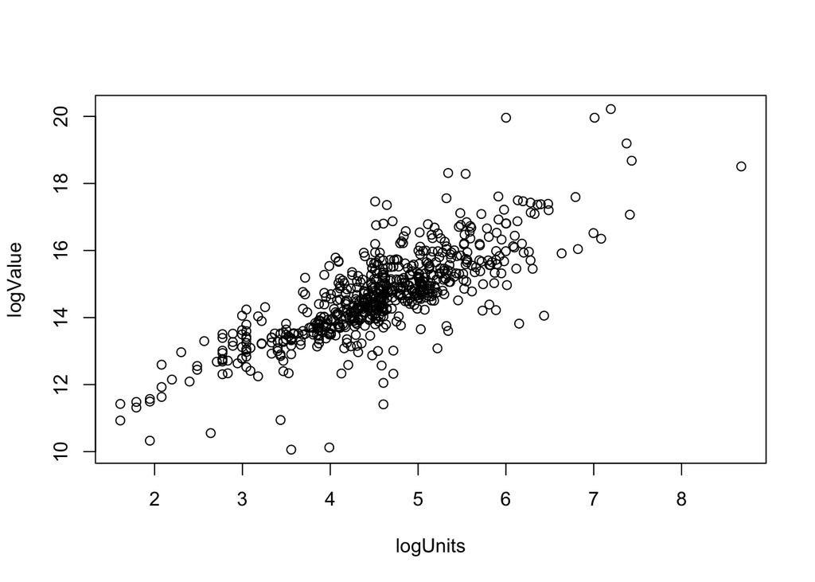

2. Makethesameplotasabove,but now include the argument col = factor(housing$after1950).

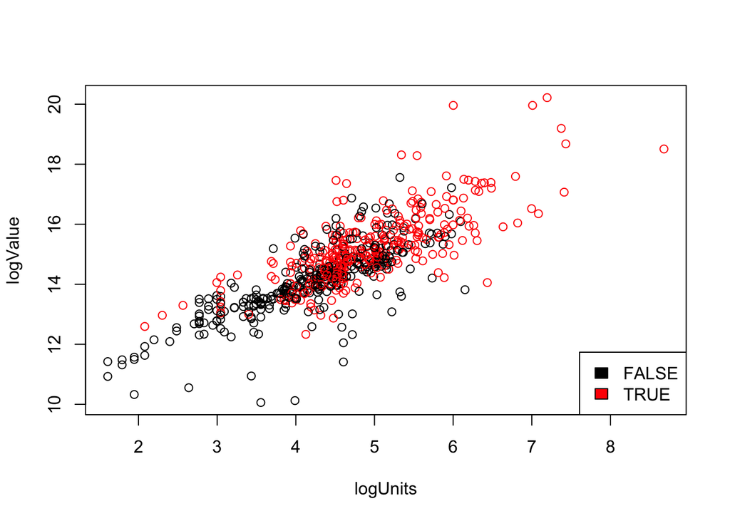

```r
plot(logValue~logUnits,col = factor(housing3$after1950))
legend("bottomright", legend = levels(factor(housing3$after1950)), fill = unique(factor(housing3$after1950)))
```

```r
#From the plot above, we can tell clearly that which poine is the "YearBuilt after 1950". The red point is the buidling built after 1950.
```

3. The cor() function calculates the correlation coefficient between two variables.

```r
#(i) the whole data
cor(logValue,logUnits)
```

```
## [1] 0.7988655
```

```r
#(ii) just Manhattan
Borough = housing3$Borough
cor(logValue[Borough=="Manhattan"],logUnits[Borough=="Manhattan"])
```

```
## [1] 0.8710823
```

```r
#(iii) just Brooklyn
cor(logValue[Borough=="Brooklyn"],logUnits[Borough=="Brooklyn"])
```

```
## [1] 0.8053241
```

```r
#(iv) for properties built after 1950
cor(logValue[after1950=="TRUE"],logUnits[after1950=="TRUE"])
```

```
## [1] 0.746731
```

```r
#(v) for properties built before 1950
cor(logValue[after1950=="FALSE"],logUnits[after1950=="FALSE"])
```

```
## [1] 0.7720285
```

4. Make two plots showing property logValue against property logUnits for Manhattan and Brooklyn.

[figure not shown]

```r
par(mfrow=c(1,2))
plot(logValue[Borough=="Manhattan"],logUnits[Borough=="Manhattan"],xlab="logUnits",ylab ="log value",main = "Manhattan")
plot(logValue[Borough=="Brooklyn"],logUnits[Borough=="Brooklyn"],xlab="logUnits",ylab ="log value",main = "Brooklyn")
```

22. Consider the following block of code.

```r
median(housing3$Value[Borough=="Manhattan"])
```

```
## [1] 3129300
```

```r
#The block of cose has the function to calculate the median value of the Manhattan
```

6. Make side-by-side box plots comparing property logValue across the five boroughs.

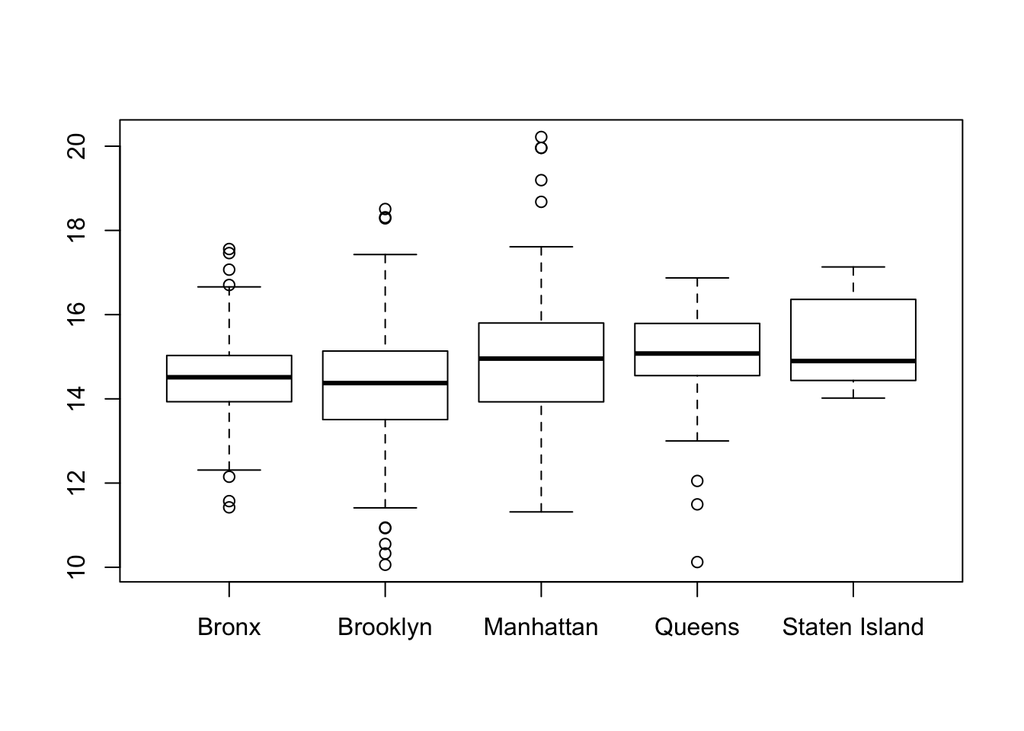

```r
par(mfrow=c(1,1))
boxplot(logValue~housing3$Borough,data = housing3)
```

7. For five boroughs, what are the median property values?

```r
median(housing3$Value[Borough=="Manhattan"])
```

```
## [1] 3129300
```

```r
median(housing3$Value[Borough=="Bronx"])
```

```
## [1] 2008260
```

```r
median(housing3$Value[Borough=="Brooklyn"])
```

```
## [1] 1749465
```

```r
median(housing3$Value[Borough=="Queens"])
```

```
## [1] 3529800
```

```r
median(housing3$Value[Borough=="Staten Island"])
```

```
## [1] 2952900
```